# Tarea 4 - Modelos Lineales

## 1. Corra un modelo de Arboles de Regresión incluyendo las variables predictoras adecuadas. Muestre e interprete alguna de las reglas obtenidas. Por último interprete las medidas de error.

```r
library(rpart)
library(rpart.plot)
library(ggplot2)

modelo.rpart <- rpart(Ventas~., data = taprendizaje, control = rpart.control(minsplit = 5, maxdepth = 25))

prediccion1 <- predict(modelo.rpart, ttesting)

Arboles <- indices.precision(ttesting$Ventas,prediccion1,numero.predictoras)

Arboles
```

```
$error.cuadratico
[1] 5.068594

$raiz.error.cuadratico
[1] 2.460092

$error.relativo
[1] 0.231875

$correlacion
[1] 0.6139512
```

Reglas obtenidas

```r
print(asRules(modelo.rpart))
```

```
 Rule number: 16 [Ventas=4.2897619047619 cover=42 (13%)]
   CalidadEstant=Malo,Medio
   Precio>=105.5
   CalidadEstant=Malo
   PrecioCompt< 144

 Rule number: 37 [Ventas=5.735 cover=38 (12%)]
   CalidadEstant=Malo,Medio
   Precio>=105.5
   CalidadEstant=Medio,Bueno
   PrecioCompt< 124.5
   Precio< 137.5

 Rule number: 39 [Ventas=8.14416666666667 cover=36 (11%)]
   CalidadEstant=Malo,Medio
   Precio>=105.5
   CalidadEstant=Medio,Bueno
   PrecioCompt>=124.5
   Precio< 127

 Rule number: 22 [Ventas=8.4871875 cover=32 (10%)]
   CalidadEstant=Malo,Medio
   Precio< 105.5
   Edad< 60.5
   PrecioCompt< 130.5

 Rule number: 77 [Ventas=6.85888888888889 cover=27 (8%)]
   CalidadEstant=Malo,Medio
   Precio>=105.5
   CalidadEstant=Medio,Bueno
   PrecioCompt>=124.5
   Precio>=127
   Publicidad>=1.5

 Rule number: 27 [Ventas=10.4464 cover=25 (8%)]
   CalidadEstant=Bueno
   Precio>=107.5
   Precio< 136.5
   Publicidad>=0.5

```

[output cut: 49 more lines]

```
 Rule number: 17 [Ventas=7.49333333333333 cover=6 (2%)]
   CalidadEstant=Malo,Medio
   Precio>=105.5
   CalidadEstant=Malo
   PrecioCompt>=144

 Rule number: 36 [Ventas=2.7325 cover=4 (1%)]
   CalidadEstant=Malo,Medio
   Precio>=105.5
   CalidadEstant=Medio,Bueno
   PrecioCompt< 124.5
   Precio>=137.5

 [1]  1  2  3  7 16 11 25  4 26 22  8  5 12 17 10 28 15 18 23 14 30 31 20 13 19
[26] 24 29 27 21  6  9
```

## 2. Ahora genere un modelo de Bosques Aleatorios usando 200 árboles y todas las variables predictoras. Cuáles son las 3 variables más importantes (basado en disminución del RSS). Por último interprete las medidas de error.

```r
library(randomForest)

modelo.randomForest <- randomForest(Ventas~., data =taprendizaje, importance = TRUE, ntree = 200, mtry = 3)

prediccion2 <- predict(modelo.randomForest, ttesting)

Bosques <- indices.precision(ttesting$Ventas,prediccion2,numero.predictoras)

Bosques
```

```
$error.cuadratico
[1] 2.706237

$raiz.error.cuadratico
[1] 1.797589

$error.relativo
[1] 0.1677597

$correlacion
[1] 0.8533815
```

Importancia de variables

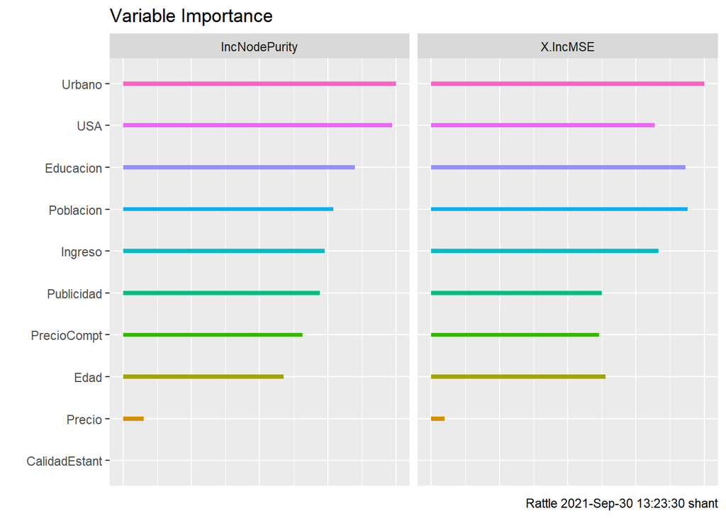

```r
ggVarImp(modelo.randomForest)
```

las 3 variables más importantes serían Urbano (Si está en zona urbana o no), USA (Si está en EEUU o no)y Educación (Años de educación promedio).